# Correlation and Causation

What are they good for?

Jeremy Springman

University of Pennsylvania

**Global Development**: Intermediate Topics in Politics, Policy, and Data

PSCI 3200 - Spring 2024

# Logistics

## Assignments

- Did everyone find the readings and slides for today?
- For next week:
  - I’ll scan the chapter and upload tonight
  - Remember you have a quasi-assignment

## Agenda

- Correlation
  - What is it?
  - What is it composed of?
  - What is it good for?
- Causation
  - What is it good for?
  - Why is it hard?
  - Potential outcomes and counterfactuals

# Correlation

## Which of the following statements describe a correlation?

1. Most professional data analysis took a statistics course in college.
2. The longer a person runs the more calories they burn.
3. People who live to be 100 years old typically take vitamins.
4. Older people vote more than younger people.

## Correlations: Quantitative Comparison

- Lots of bad analysis *implies* comparisons
  - Ex. 10 things that extremely successful people do to be productive
  - Ex. 60% of Americans now live paycheck-to-paycheck
  - Ex. 70% of participants reported an improvement
- Avoid ‘selecting on the dependent variable’
  - Applies to qualitative comparisons as well

## Correlations: Necessary Components

**What do we need to calculate correlations?**

- Measures of central tendency
  - Mean
- Measures of spread
  - Variance
  - Standard deviation

## Central Tendency: Mean

$$\mu_X = \frac{1}{n} \sum_{i}^{n} X_i$$

```r
my_vector = rnorm(10, mean = 10, sd = 5)
# Step 1: Sum the values
sum_values <- sum(my_vector)
# Step 2: Count the number of elements
count_elements <- length(my_vector)
# Step 3: Calculate the mean
mean_value <- sum_values / count_elements

print(mean_value)
```

```
[1] 10.14872
```

```r
mean(my_vector)
```

```
[1] 10.14872
```

## Spread: Variance

$$\sigma^2_X = \frac{1}{N} \sum_{i}^{N} (X_i - \mu_X)^2$$

- What does the square in $\sigma^2$ accomplish?
- What are the implications for interpretation?
  - Units
  - Distribution
- Even with these basic measures, we’re already thinking about the distribution!

## Spread: Variance

**Create a vector**

```r
## Create vector, sort by size, and store var
set.seed(123)
dat = rnorm(10, mean = 10, sd = 5)
dat = sort(dat)
o_var = var(dat)
print(dat)
```

```
 [1]  3.674694  6.565736  7.197622  7.771690  8.849113 10.352542 10.646439
 [8] 12.304581 17.793542 18.575325
```

**Add a constant to a big number**

```r
## Create new dataframe for big addition and store vector length
b_dat = dat
ind = length(b_dat)

## Add four to the largest number in the vector and calculate size of var increase
b_dat[ind] = b_dat[ind] + 4
b_var = var(b_dat)
val = b_var - o_var
cat("Variance increases by", val )
```

```
Variance increases by 8.890842
```

**Add a constant to a smaller number**

```r
## Create new dataframe for small addition
s_dat = dat

## Add four to the smallest number in the vector and calculate size of var increase
s_dat[ind-2] = s_dat[ind-2] + 4
s_var = var(s_dat)
val = s_var - o_var
cat("Variance increases by", val )
```

```
Variance increases by 3.316847
```

## Spread: Standard Deviation

$$\sigma_X = \sqrt{\frac{1}{N} \sum_{i}^{N} (X_i - \mu_X)^2}$$

- What does the $\sqrt{}$ accomplish?
- What are the implications for interpretation?
  - Expressed in the same units as the observations
  - How far we expect each observation to be from the mean, on average
- This means we can report effect sizes as SDs

## Measures of Correlation

- Covariance $\text{Cov}(X, Y) = \frac{1}{n} \sum_{i}^{N} (X_i - \bar{X})(Y_i - \bar{Y})$
  - Product of the deviations
  - Range: unbounded
- Correlation coefficient $\text{Cor}(X, Y) = \frac{\text{Cov}(X, Y)}{\sigma_X \sigma_Y}$
  - Covariance normalized by product of SDs
  - Range: -1 to 1
- Slope $\beta_X = \frac{\text{Cov}(X, Y)}{\sigma^2_X}$
  - Covariance normalized by variance
  - Expected change in $Y$ with 1-unit change in $X$

## Measures of Correlation

- What does the correlation coefficient tell you that slope doesn’t?
  - Consistency of the relationship on bounded scale (-1 to 1)
- What does slope tell you that the correlation coefficient doesn’t?
  - Substantive importance (magnitude)
- Give an example of when you’d prefer each
  - Correlation: When comparing relationships on different scales
  - Slope: When thinking about ROI

## Correlation

**What can with do with them?**

- Description: quantitative comparisons
- *sample matters alot*
- *sample matters less*
- Forecasting: sample population $\rightarrow$ out-of-sample
- Causal inference: correlation + research design

**Simple, but powerful**

- Non-linearities, interactions, machine learning

# Causation

## Schools of Thought

- Potential outcomes and counterfactuals (Econ)
- DAGs and do-calculus (CS)
- Manipulability (Philosophy)

“We think of a cause as something that makes a difference, and the difference it makes must be a difference from what would have happened without it.” (Lewis, 1973)

## Causality: Why bother?

- Understanding cause and effect is how we change things in the real world
- Causal inference separates good evaluations from bad
  - Policy change
  - Development intervention
- Causal identification is not binary
  - It’s harder for some policies and interventions than others
  - Variety of tools that can help us rule out different threats to inference

## Causality: Why bother?

```r
library(ggplot2)

Year = c(0,1,2,3)
Outcome = c(NA, 1.2, 1.4,NA)
Treatment = c("Control", "Control","Control","Control")

dat = data.frame(Year, Outcome, Treatment)

ggplot(data = dat, aes(x = Year, y = Outcome, group = Treatment)) +
  geom_line(aes(linetype=Treatment),size=2) +
  geom_point(size = 6) +
  scale_linetype_manual(values=c("solid")) +
  xlim(0,3) +
  scale_y_continuous(limits = c(1,1.85), breaks = seq(1, 1.85, by = .1)) +
  theme(legend.position = "none", text = element_text(size=20))
```

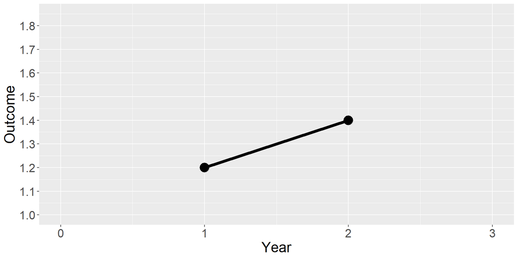

## Causality: Why bother?

```r
Year = c(0,1,2,3)
Outcome = c(1, 1.2, 1.4, 1.6,
            0.9, 1.3, 1.7, 2.1)
Treatment = c("Control", "Control","Control","Control",
              "Treatment", "Treatment", "Treatment", "Treatment")

dat = data.frame(Year, Outcome, Treatment)


ggplot(data = dat, aes(x = Year, y = Outcome, group = Treatment)) +
  geom_line(aes(linetype=Treatment),size=2) +
  geom_point(size = 6) +
  xlim(0,3) +
  scale_y_continuous(breaks = seq(1, 1.85, by = .1)) +
  scale_linetype_manual(values=c("solid", "solid")) +
  coord_cartesian(ylim = c(1, 1.85), clip = "on") +
  theme(legend.position = "none", text = element_text(size=20))
```

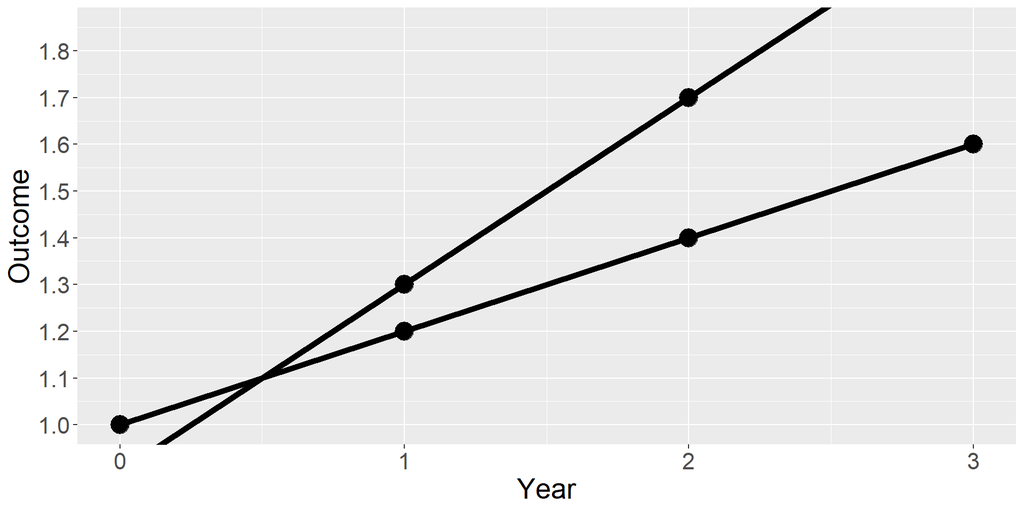

## Causality: Why bother?

```r
Year = c(0,1,2,3)
Outcome = c(1, 1.2, 1.4,1.6)
Treatment = c("Control", "Control","Control","Control")

dat = data.frame(Year, Outcome, Treatment)

ggplot(data = dat, aes(x = Year, y = Outcome, group = Treatment)) +
  geom_line(aes(linetype=Treatment),size=2) +
  geom_point(size = 6) +
  scale_linetype_manual(values=c("solid")) +
  xlim(0,3) +
  scale_y_continuous(limits = c(1,1.85), breaks = seq(1, 1.85, by = .1)) +
  theme(legend.position = "none", text = element_text(size=20))
```

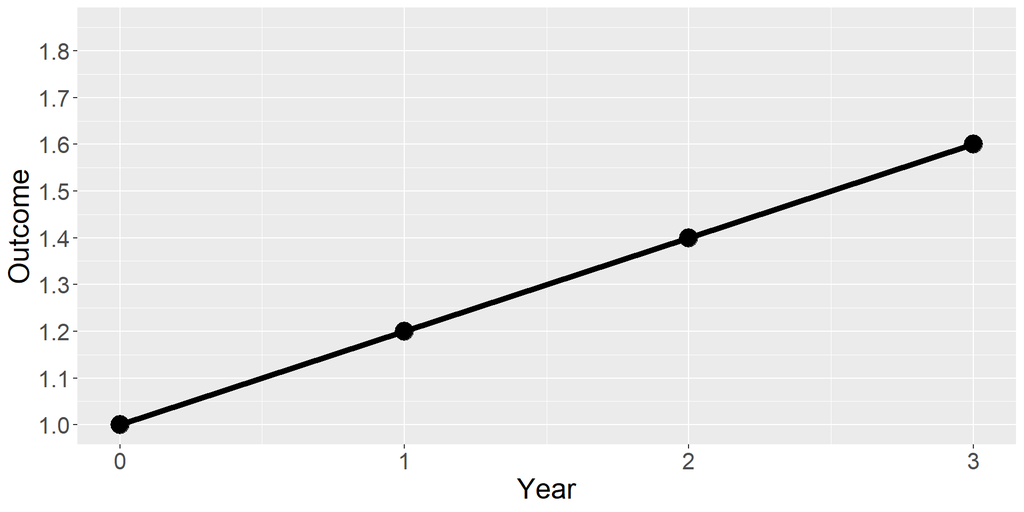

## Causality: Why bother?

```r
Year = c(0,1,2,3)
Outcome = c(NA, 1.2, 1.4, NA,
            NA, 1.3, 1.7, NA,
            NA, 1.3, 1.5, NA)
Treatment = c("Control", "Control","Control","Control",
              "Treatment", "Treatment", "Treatment", "Treatment",
              "Comparison","Comparison","Comparison","Comparison")

dat = data.frame(Year, Outcome, Treatment)


ggplot(data = dat, aes(x = Year, y = Outcome, group = Treatment)) +
  geom_line(aes(linetype=Treatment),size=2) +
  geom_point(size = 6) +
  xlim(0,3) +
  scale_y_continuous(limits = c(1,1.85), breaks = seq(1, 1.85, by = .1)) +
  scale_linetype_manual(values=c("dotted", "solid", "solid")) +
  theme(legend.position = "none", text = element_text(size=20))
```

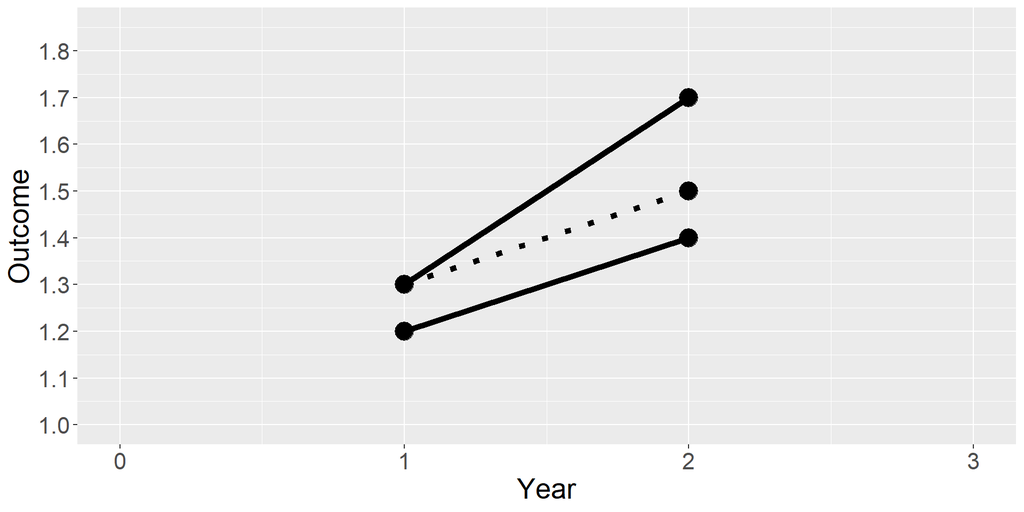

## Causality: Why bother?

```r
Year = c(0,1,2,3)
Outcome = c(NA, 1.2, 1.4, NA,
            NA, 1.3, 1.7, NA)
Treatment = c("Control", "Control","Control","Control",
              "Treatment", "Treatment", "Treatment", "Treatment")

dat = data.frame(Year, Outcome, Treatment)


ggplot(data = dat, aes(x = Year, y = Outcome, group = Treatment)) +
  geom_line(aes(linetype=Treatment),size=2) +
  geom_point(size = 6) +
  xlim(0,3) +
  scale_y_continuous(limits = c(1,1.85), breaks = seq(1, 1.85, by = .1)) +
  scale_linetype_manual(values=c("solid", "solid")) +
  theme(legend.position = "none", text = element_text(size=20))
```

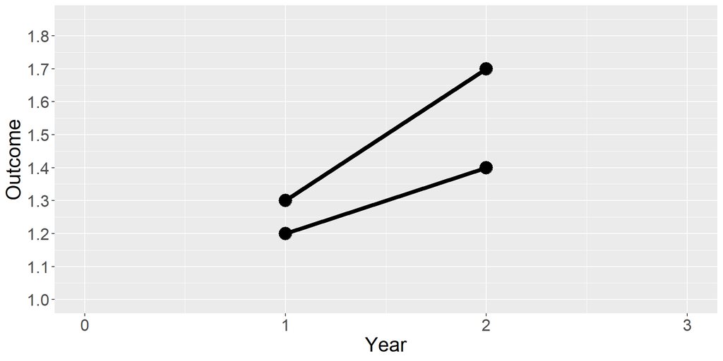

## Causality: Why bother?

```r
ear = c(0,1,2,3)
Outcome = c(1, 1.2, 1.4,1.6,
            1.1, 1.3, 1.7, 1.9,
            1.1, 1.3, 1.5, 1.7)
Treatment = c("Control", "Control","Control","Control",
              "Treatment", "Treatment", "Treatment", "Treatment",
              "Comparison","Comparison","Comparison","Comparison")

dat = data.frame(Year, Outcome, Treatment)


ggplot(data = dat, aes(x = Year, y = Outcome, group = Treatment)) +
  geom_line(aes(linetype=Treatment),size=2) +
  geom_point(size = 6) +
  scale_y_continuous(breaks = seq(1, 1.9, by = .1)) +
  scale_linetype_manual(values=c("dotted", "solid", "solid")) +
  coord_cartesian(ylim = c(1, 1.85), clip = "on") +
  theme(legend.position = "none", text = element_text(size=20))
```

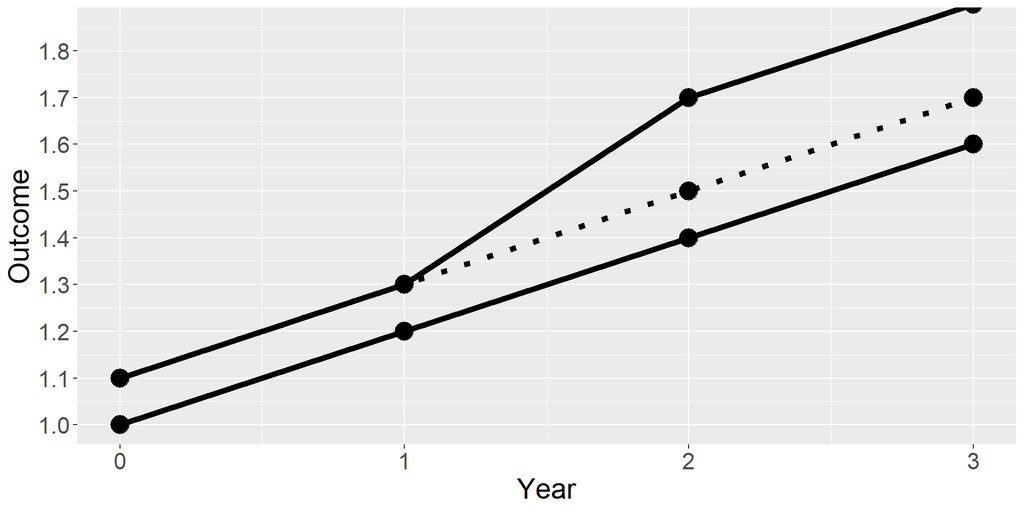

## Causality: Why bother?

```r
Year = c(0,1,2,3)
Outcome = c(1, 1.2, 1.4,1.6,
            1.1, 1.3, 1.7, 1.9)
Treatment = c("Control", "Control","Control","Control",
              "Treatment", "Treatment", "Treatment", "Treatment")

dat = data.frame(Year, Outcome, Treatment)


ggplot(data = dat, aes(x = Year, y = Outcome, group = Treatment)) +
  geom_line(aes(linetype=Treatment),size=2) +
  geom_point(size = 6) +
  scale_y_continuous(breaks = seq(1, 1.9, by = .1)) +
  scale_linetype_manual(values=c("solid", "solid")) +
  coord_cartesian(ylim = c(1, 1.85), clip = "on") +
  theme(legend.position = "none", text = element_text(size=20))
```

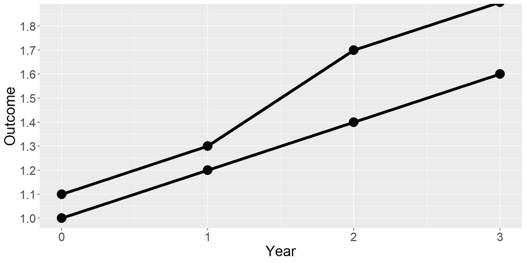

## Causality: What makes it hard?

**Fundamental Problem of Causal Inference**

$$Y_i =
\begin{cases}
Y_i(1) & \text{if } D_i = 1 \text{ (treatment group)} \\
Y_i(0) & \text{if } D_i = 0 \text{ (control group)}
\end{cases}$$

- We only observe any given unit in one treatment status at any one time so we can never directly observe the causal effect of a treatment on a unit.

## Potential Outcomes and Counterfactuals

**Treatment Effect for individual $i$**

- $TE_i = Y_i(1) - Y_i(0)$

**Average Treatment Effect (ATE)**

- $ATE = \frac{1}{N} \sum_{i=1}^{N} TE_i$

## Many Different Tools

- Randomized experiments
  - Gold-standard
  - Field and survey
- Observational data
  - Natural experiments
  - Difference-in-Differences
  - Matching, Synthetic Control

## DAGs and Confounding

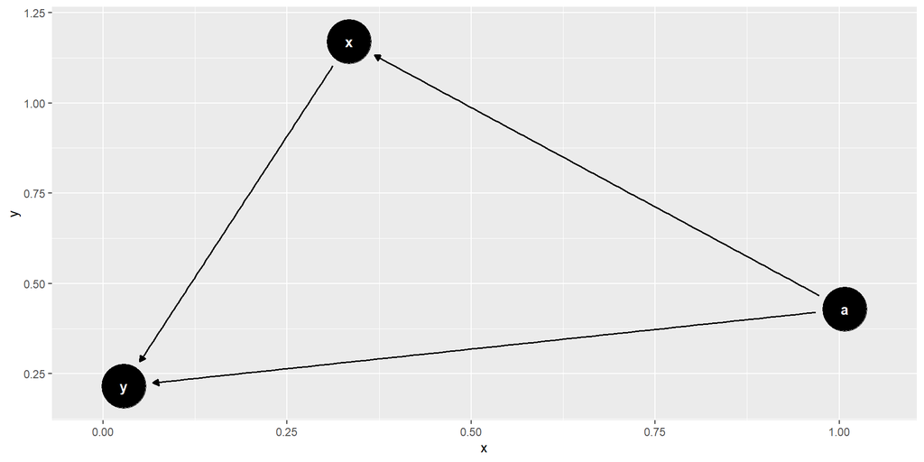

## Next Meeting

- Randomized experiments
  - Review of FPCI
  - How randomization addresses confounding
- The role of social science researchers?
  - What should people with social science training be doing with their skills?
- Final Project
  - What are your options?
  - Possible data sources

[figure not shown]

jrspringman.github.io/psci3200-globaldev/